# CUNY DATA 621 Homework 4

Raphael Nash

# Exploration

```r
summary(training_df )
```

[output not shown]

Plot histograms for continous data

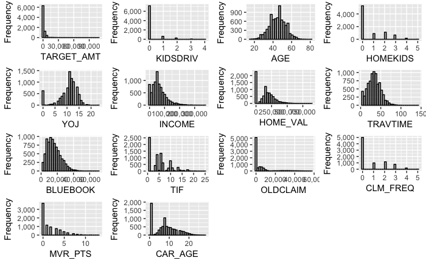

# Transformation

3)Fill missing values with median

# Builid models

## Logistical Regression.

Build Logistical Regression model to predict if person has a claim (TARGET_FLAG). Of course inorder to do theis we will have to remove TARGET_AMT and INDEX from the dataframe. INDEX truely has not value, and you only have a claim amoiunt if you have a claim. I will use backward selection to select the best logistical model.  
### Model 1

In this iteration, I will remove all values from the model where all levels of that variable do not have a p value of <.001. This will get our model focusing on the mose signifigant values. This model will predict TARGET_FLAG based on HOME_VAL, MSTATUS, TRAVTIME, CAR_USE, BLUEBOOK, TIF, CAR_TYPE, OLDCLAIM, CLM_FREQ, REVOKED, MVR_PTS, URBANICITY

### Model 1

This model will contain all variables.

### Model 2

From regression model I am am going to drop all but the statisticall signifigant variables. This model will predict target amount based on BLUEBOOK, REVOKED, CAR_AGE, EDUCATION

### Model 3

For this model I will again drop all but the most signifigant variabels. That will mean this model will predict claim amout based on car age and blue book.

### Model 4

# Model Selection

# Appendix R Code

library(ggplot2) library(reshape2) library(corrplot) library(forecast) library(dplyr) library(Deducer) library(tidyr) library(DataExplorer) library(speedglm)

## Exploration

training_df <- read.csv (“insurance_training_data.csv”) eval_df <- read.csv(“insurance-evaluation-data.csv”) head(training_df)

summary(training_df)

histogram_df <- training_df[, c( “TARGET_AMT”, “KIDSDRIV”, “AGE”,“HOMEKIDS”, “YOJ”, “INCOME” , “HOME_VAL”, “TRAVTIME”, “BLUEBOOK”, “TIF”, “OLDCLAIM”, “CLM_FREQ”, “MVR_PTS”, “CAR_AGE”)]

plot_histogram(histogram_df)

bar_df <- training_df[,c(“PARENT1”,“MSTATUS”,“SEX”,“EDUCATION”,“JOB”,“CAR_USE”,“CAR_TYPE”, “RED_CAR”,“REVOKED”,“URBANICITY”) ]

plot_bar(bar_df)

## Transformation

training_df$CAR_AGE[training_df$CAR_AGE < 0 ] <- 0 training_df$JOB <- as.character(training_df$JOB) training_df$JOB[training_df$JOB == “”] <- “Unknown” training_df$JOB <- as.factor(training_df$JOB) training_df$INCOME <- as.numeric(gsub('[$,]‘,’‘, training_df$INCOME)) training_df$HOME_VAL <- as.numeric(gsub(’[$,]‘,’‘, training_df$HOME_VAL)) training_df$BLUEBOOK <- as.numeric(gsub(’[$,]‘,’‘, training_df$BLUEBOOK)) training_df$OLDCLAIM <- as.numeric(gsub(’[$,]‘,’‘, training_df$OLDCLAIM)) eval_df$CAR_AGE[eval_df$CAR_AGE < 0 ] <- 0 eval_df$JOB <- as.character(eval_df$JOB) eval_df$JOB[eval_df$JOB == “”] <- “Unknown” eval_df$JOB <- as.factor(eval_df$JOB) eval_df$INCOME <- as.numeric(gsub('[$,]’, ‘’, eval_df$INCOME)) eval_df$HOME_VAL <- as.numeric(gsub(’[$,]‘,’‘, eval_df$HOME_VAL)) eval_df$BLUEBOOK <- as.numeric(gsub(’[$,]‘,’‘, eval_df$BLUEBOOK)) eval_df$OLDCLAIM <- as.numeric(gsub(’[$,]‘,’’, eval_df$OLDCLAIM))

3)Fill missing values with median

training_df$AGE[is.na(training_df$AGE)] = median(training_df$AGE, na.rm=TRUE) training_df$CAR_AGE[is.na(training_df$CAR_AGE)] = median(training_df$CAR_AGE, na.rm=TRUE) training_df$INCOME[is.na(training_df$INCOME)] = median(training_df$INCOME, na.rm=TRUE) training_df$YOJ[is.na(training_df$YOJ)] = median(training_df$YOJ, na.rm=TRUE) training_df$HOME_VAL[is.na(training_df$HOME_VAL)] = median(training_df$HOME_VAL, na.rm=TRUE)

eval_df$AGE[is.na(eval_df$AGE)] = median(eval_df$AGE, na.rm=TRUE) eval_df$CAR_AGE[is.na(eval_df$CAR_AGE)] = median(eval_df$CAR_AGE, na.rm=TRUE) eval_df$INCOME[is.na(eval_df$INCOME)] = median(eval_df$INCOME, na.rm=TRUE) eval_df$YOJ[is.na(eval_df$YOJ)] = median(eval_df$YOJ, na.rm=TRUE) eval_df$HOME_VAL[is.na(eval_df$HOME_VAL)] = median(eval_df$HOME_VAL, na.rm=TRUE)

## Builid models

### Logistical Regression.

#### Model 1

trainng_logit_df <- training_df[ , !names(training_df) %in% c(“INDEX”, “TARGET_AMT”) ]

logit_model1 <- glm (TARGET_FLAG ~ . , family = ‘binomial’, data=trainng_logit_df ) summary(logit_model1)

#### Model 2

logit_model2 <- glm (TARGET_FLAG ~ INCOME+ PARENT1 + HOME_VAL+ MSTATUS+EDUCATION+JOB+ TRAVTIME +CAR_USE+ BLUEBOOK + TIF+ CAR_TYPE+OLDCLAIM+CLM_FREQ+REVOKED+MVR_PTS+URBANICITY , family = ‘binomial’, data=trainng_logit_df ) summary(logit_model2)

### MODEL 3

logit_model3 <- glm (TARGET_FLAG ~ HOME_VAL+ MSTATUS+ TRAVTIME +CAR_USE+ BLUEBOOK + TIF+ CAR_TYPE+OLDCLAIM+CLM_FREQ+REVOKED+MVR_PTS+URBANICITY , family = ‘binomial’, data=trainng_logit_df ) summary(logit_model3)

### Claim Amount Regression Model

#### Model 1

regression_training_df <- training_df[training_df$TARGET_FLAG == 1, ] regression_training_df <- regression_training_df[ , !names(regression_training_df) %in% c(“INDEX”, “TARGET_FLAG”) ]

reg_model1 <- lm(TARGET_AMT ~., data = regression_training_df) summary(reg_model1)

#### Model 2

reg_model2 <- lm(TARGET_AMT ~BLUEBOOK + REVOKED + CAR_AGE + EDUCATION, data = regression_training_df) summary(reg_model2)

#### Model 3

reg_model3 <- lm(TARGET_AMT ~BLUEBOOK + CAR_AGE , data = regression_training_df) summary(reg_model3)

#### Model 4

reg_model4 <- lm(TARGET_AMT ~BLUEBOOK , data = regression_training_df) summary(reg_model4)

## Model Selection

### Model Selection Logistical Regression

rocplot(logit_model1)

rocplot(logit_model2)

rocplot(logit_model3)

### Claim Amount Regression Model Selection

## Make Predications

probs <- predict(logit_model3,eval_df) prediction <- ifelse ( probs > .5 ,1,0)

eval_df$TARGET_FLAG<-prediction

eval_df$TARGET_AMT <- with(eval_df , ifelse ( TARGET_FLAG ==0, BLUEBOOK* reg_model4$coefficients[2] + reg_model4$coefficients[1],0) )

head(eval_df)